# Mini-Challenge 2 – Day 1: Data & Domain

## Day 1 - Data & Domain

### Use Case

In the context of alpine wildlife monitoring and automated population census programs, images are generated by camera traps and field photography and captured using trail cameras and digital camera sensors in order to detect and document Alpine ibex under natural conditions. These images are used by Swiss National Park rangers, cantonal wildlife offices, and conservation biologists to perform population monitoring and habitat-use assessment. This use case is particularly relevant for Switzerland because ibex monitoring is performed in steep high-alpine terrain where automated, image-based observation is essential for scalable and repeatable surveys.

### Problem Statement

This project addresses the problem of limited visual variability and unstable illumination within Swiss alpine wildlife monitoring. If models are trained on a narrow set of lighting and background conditions, performance may degrade when sky brightness, rock reflectance, and sensor noise change, leading to missed detections. Preserving the ibex fur-to-background boundary (fur against sky and fur against grey rock) is essential for reliable detection in this use case.

### Experimental Objective

The objective of this project is to investigate how illumination variation and sensor-like noise influence boundary and texture visibility of Alpine ibex in Swiss mountain imagery, in order to better understand which image properties should be varied while keeping key detection-relevant structures recognizable.

### Data Definition, Source, and Visualization

The selected image represents two Alpine ibex in a Swiss alpine scene and was captured using a consumer digital camera in outdoor mountain conditions, expressed in RGB color space after loading. Relevant characteristics include dark fur textures, boundary edges against bright sky and grey rock, and local contrast variation caused by natural illumination. These characteristics are important because the augmentation objective focuses on robustness to lighting and noise while preserving contour and texture cues. The data originate from a personal photograph stored in `Challenges MC2/Data/Steinbock.jpg`, and are appropriate because they directly reflect realistic Swiss field-monitoring conditions.

```
Shape : (3024, 4032, 3)  (width x height x channels)
Dtype : uint8
Min   : 0
Max   : 255
```

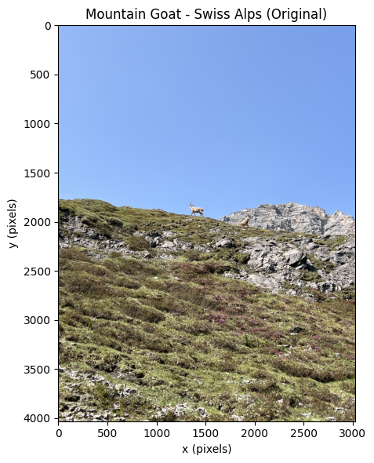

```python
import numpy as np
import matplotlib.pyplot as plt
from PIL import Image

img_path = "Data/Steinbock.jpg"
img = np.array(Image.open(img_path).convert("RGB"))

# rotate 90 degrees clockwise
img = np.rot90(img, k=-1)
h, w, c = img.shape

print(f"Shape : ({w}, {h}, {c})  (width x height x channels)")
print(f"Dtype : {img.dtype}")
print(f"Min   : {img.min()}")
print(f"Max   : {img.max()}")

fig, ax = plt.subplots(figsize=(9, 6))
ax.imshow(img)
ax.set_title("Mountain Goat - Swiss Alps (Original)")
ax.set_xlabel("x (pixels)")
ax.set_ylabel("y (pixels)")
plt.tight_layout()
plt.show()
```

**Observations**: The visualization shows two Alpine ibex in the same Swiss alpine scene: one appears against a bright sky background and the other appears against grey rock. This creates two boundary conditions, with stronger dark-fur-to-sky contrast and lower dark-fur-to-rock contrast. These paired contexts are relevant for wildlife monitoring because detection robustness must hold for both high-contrast and lower-contrast contour conditions.

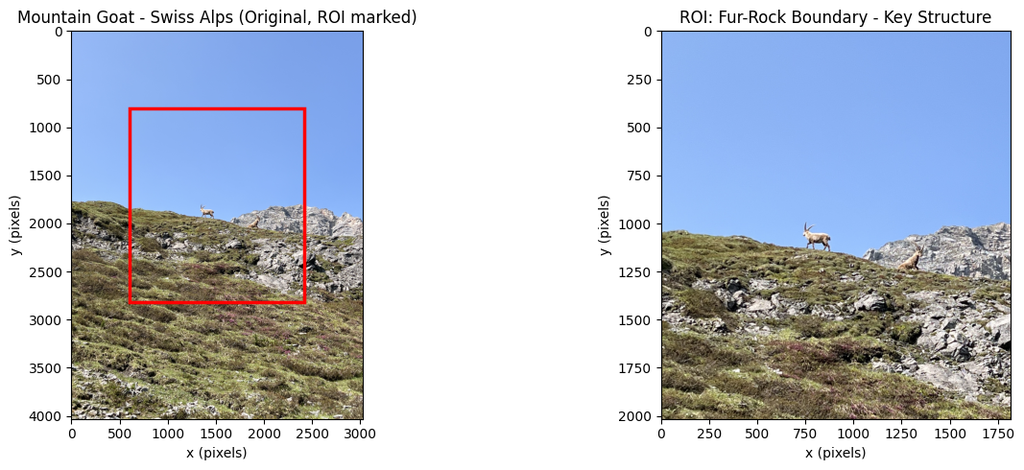

```python
y0, y1 = int(h * 0.20), int(h * 0.70)
x0, x1 = int(w * 0.20), int(w * 0.80)
roi = img[y0:y1, x0:x1]

fig, axes = plt.subplots(1, 2, figsize=(14, 5))

axes[0].imshow(img)
axes[0].add_patch(
    plt.Rectangle((x0, y0), x1 - x0, y1 - y0, edgecolor="red", facecolor="none", linewidth=2.5)
)
axes[0].set_title("Mountain Goat - Swiss Alps (Original, ROI marked)")
axes[0].set_xlabel("x (pixels)")
axes[0].set_ylabel("y (pixels)")

axes[1].imshow(roi)
axes[1].set_title("ROI: Fur-Rock Boundary - Key Structure")
axes[1].set_xlabel("x (pixels)")
axes[1].set_ylabel("y (pixels)")

plt.tight_layout()
plt.show()
```

**Observations (ROI)**: This ROI was selected because it captures central ibex body contours together with adjacent background, including fur-to-rock transitions while the full image also contains fur-to-sky transitions. In this region, fur texture is visibly distinct from nearby stone texture, and contour edges are clearly traceable. This directly supports the Day 1 objective of preserving detection-relevant structure under mixed Swiss alpine backgrounds.

## Day 2 - Methodological Design

### Theoretical Foundation and Method Choice

Two non-geometric augmentations are selected to match the Day 1 challenge. **(1) Gamma correction** applies a nonlinear intensity transform to simulate illumination shifts typical of alpine sun, shadow, and haze. **(2) Additive Gaussian noise** simulates sensor noise that can reduce local boundary clarity. These methods are appropriate because the key structure is the ibex fur-to-background contour (sky-backed and rock-backed), where both intensity remapping and noise directly affect edge visibility and texture discrimination.

### Parameter Definition and Mathematical Specification

For gamma correction, the transformation is `I_out = 255 * (I_in / 255)^gamma`. Key parameter: **gamma**. Values `< 1` brighten darker tones and compress contrast near highlights, which changes fur-shading and sky/rock separability. For noise, the transformation is `I_out = clip(I_in + n, 0, 255)` with `n ~ N(0, sigma^2)`. Key parameter: **sigma** controls noise amplitude; larger sigma increases random texture perturbation and weakens fine contour detail in fur and boundary regions.

### Experimental Design for Next Days

The target change is controlled illumination-noise variability while preserving identifiable ibex structure.

| Configuration | Gamma | Noise sigma | Purpose |
| --- | --- | --- | --- |
| C0 Baseline | 1.00 | 0 | Reference without synthetic change |
| C1 Moderate | 0.90 | 8 | Realistic moderate lighting/noise shift |
| C2 Strong | 0.75 | 16 | Strong stress-test of boundary/texture stability |

Controlled variables across all configurations: same input image, same ROI coordinates, same processing order (gamma then noise), and fixed random seed for reproducibility.

### Methodological Limitations and Risk Factors

Gamma and Gaussian models are useful approximations but do not capture all alpine effects (e.g., directional glare, weather-dependent veiling, motion blur). Over-strong parameters can create unrealistic textures and may teach models to rely on synthetic artifacts. Therefore, a small, traceable parameter set is used to support controlled comparison rather than broad random generation.

## Day 3 - Technical Implementation

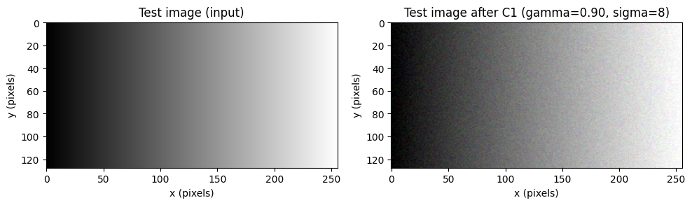

```python
import numpy as np
import matplotlib.pyplot as plt
from PIL import Image

img = np.array(Image.open("Data/Steinbock.jpg").convert("RGB"))
img = np.rot90(img, k=-1)
h, w, _ = img.shape
y0, y1 = int(h * 0.20), int(h * 0.70)
x0, x1 = int(w * 0.20), int(w * 0.80)

configs = {
    "C0 Baseline": {"gamma": 1.00, "sigma": 0.0, "seed": 26},
    "C1 Moderate": {"gamma": 0.90, "sigma": 8.0, "seed": 26},
    "C2 Strong": {"gamma": 0.75, "sigma": 16.0, "seed": 26},
}

def adjust_gamma(image, gamma):
    if abs(gamma - 1.0) < 1e-12:
        return image.copy()
    x = np.linspace(0, 1, 256)
    lut = np.clip((x ** gamma) * 255, 0, 255).astype(np.uint8)
    return lut[image]

def add_gaussian_noise(image, sigma, seed=26):
    if sigma <= 0:
        return image.copy()
    rng = np.random.default_rng(seed)
    noisy = image.astype(np.float32) + rng.normal(0, sigma, image.shape)
    return np.clip(noisy, 0, 255).astype(np.uint8)

def apply_config(image, cfg):
    out = adjust_gamma(image, cfg["gamma"])
    out = add_gaussian_noise(out, cfg["sigma"], cfg["seed"])
    return out

# Functionality check on a simple synthetic test image
grad = np.tile(np.linspace(0, 255, 256, dtype=np.uint8), (128, 1))
test_img = np.dstack([grad, grad, grad])
test_aug = apply_config(test_img, configs["C1 Moderate"])

fig, axes = plt.subplots(1, 2, figsize=(10, 3.5))
axes[0].imshow(test_img)
axes[0].set_title("Test image (input)")
axes[1].imshow(test_aug)
axes[1].set_title("Test image after C1 (gamma=0.90, sigma=8)")
for ax in axes:
    ax.set_xlabel("x (pixels)")
    ax.set_ylabel("y (pixels)")
plt.tight_layout()
plt.show()
```

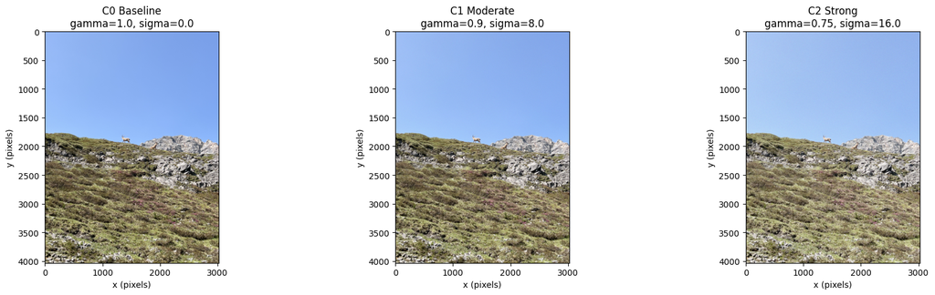

```python
augmented = {name: apply_config(img, cfg) for name, cfg in configs.items()}

fig, axes = plt.subplots(1, 3, figsize=(18, 5))
for ax, (name, cfg) in zip(axes, configs.items()):
    ax.imshow(augmented[name])
    ax.set_title(f"{name}\ngamma={cfg['gamma']}, sigma={cfg['sigma']}")
    ax.set_xlabel("x (pixels)")
    ax.set_ylabel("y (pixels)")
plt.tight_layout()
plt.show()
```

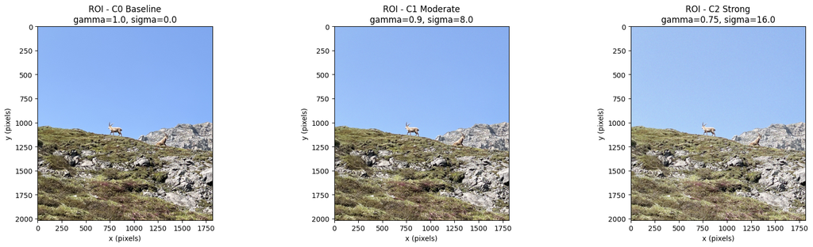

```python
fig, axes = plt.subplots(1, 3, figsize=(18, 5))
for ax, (name, cfg) in zip(axes, configs.items()):
    roi_aug = augmented[name][y0:y1, x0:x1]
    ax.imshow(roi_aug)
    ax.set_title(f"ROI - {name}\ngamma={cfg['gamma']}, sigma={cfg['sigma']}")
    ax.set_xlabel("x (pixels)")
    ax.set_ylabel("y (pixels)")
plt.tight_layout()
plt.show()
```